# Task 1 & 2

Grace Bianchi

2023-01-25

**Background**

This code examines and wrangles amphibian data collected in the Sierra Lakes from 1995 to 2002. The mountain yellow-legged frog data is analyzed further to see the total number of observations during this study and the lakes with the most observations.

Data variable included in this analysis: - lake_id - amphibian_species: Rana muscosa (RAMU) - amphibian_life_stage: Eggmass, tadpole, subadult, adult. - amphibian_number: number observed

**Data Citation:** Knapp, R.A., C. Pavelka, E.E. Hegeman, and T.C. Smith. 2020. The Sierra Lakes Inventory Project: Non-Native fish and community composition of lakes and ponds in the Sierra Nevada, California ver 2. Environmental Data Initiative. https://doi.org/10.6073/pasta/d835832d7fd00d9e4466e44eea87fab3

### Setup

```r
knitr::opts_chunk$set(echo = TRUE, message = FALSE, warning = FALSE)

library(here)
library(tidyverse)
library(patchwork)
library(readxl)
library(lubridate)
library(cowplot)
```

```r
sierra_amphibians_data <- read_xlsx(here("sierra_amphibians.xlsx")) %>%
  mutate(survey_date = ymd(survey_date),
         year = year(survey_date))
```

A graph of total mountain yellow-legged frog (Rana muscosa) count each year across all water bodies, by life stage excluding the ‘EggMass’ level. the total number of adult, subadult, and tadpole yellow-legged frogs observed in the entire study region by life stage and year

### Total Mountain yellow-legged frog observations

```r
yellow_legged_frog <- sierra_amphibians_data %>%
  filter(amphibian_species == "RAMU", # filter for yellow-legged frog
         amphibian_life_stage != "EggMass") # remove any eggmass observations

yellow_frog_summary <- yellow_legged_frog %>%
  group_by(year, amphibian_life_stage) %>%
  summarise(n = sum(amphibian_number))

p1 <- ggplot(data = yellow_frog_summary, aes(x = year, y = n)) +
  geom_col(aes(fill = amphibian_life_stage)) +
  theme_light() +
  labs(x = "Year", y = "Total Observed Counts (n)") +
  guides(fill=guide_legend(title="Life Stage")) + # change legend title
  theme(legend.position = c(0.2, 0.75))
```

```r
yellow_frog_lake <- yellow_legged_frog %>%
  filter(amphibian_life_stage != "Tadpole") %>% # remove tadpole observations
  group_by(lake_id) %>%
  summarize(n = sum(amphibian_number)) %>% # find counts for each lake
  slice_max(n = 5, order_by = (n)) # select lakes with highest counts

# add Lake before each id number
yellow_frog_lake$lake_id <- sub("^", "Lake ", yellow_frog_lake$lake_id)

p2 <- ggplot(data = yellow_frog_lake, aes(x = reorder(lake_id, n), y = n)) +
  geom_col(fill = "lightblue", show.legend = FALSE) +
  theme_light() +
  labs(y = " ",
       x = " ")
```

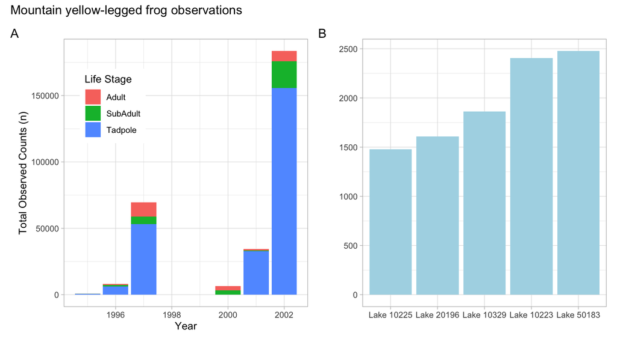

```r
p1   + p2 +
  plot_annotation(title = 'Mountain yellow-legged frog observations', tag_levels = "A")
```

Figure 1. A) Graph of the number of mountain yellow-legged frogs (Rana muscosa) observed since 1995 by life stage. B) Top 5 lakes with the highest number of observations of adult and subadult frogs from 1995 to 2002.